# Red Wine - Project 5

Mariam Abouzeid

January 24, 2019

# Red Wine Quality Exploration by Mariam_Abouzeid

# Introduction

This project aims at use R and exploratory data analysis techniques to explore a The Red Wine dataset, that i have chosen from the availbe datasets.

This dataset has around 1600 records with 12 different attributes.

We will go through Univariate, Bivariate and Multivariate Analysis.

First, Let’s take a look at the dataset summary

```
##  fixed.acidity   volatile.acidity  citric.acid    residual.sugar
##  Min.   : 4.60   Min.   :0.1200   Min.   :0.000   Min.   : 0.900
##  1st Qu.: 7.10   1st Qu.:0.3900   1st Qu.:0.090   1st Qu.: 1.900
##  Median : 7.90   Median :0.5200   Median :0.260   Median : 2.200
##  Mean   : 8.32   Mean   :0.5278   Mean   :0.271   Mean   : 2.539
##  3rd Qu.: 9.20   3rd Qu.:0.6400   3rd Qu.:0.420   3rd Qu.: 2.600
##  Max.   :15.90   Max.   :1.5800   Max.   :1.000   Max.   :15.500
##    chlorides       free.sulfur.dioxide total.sulfur.dioxide
##  Min.   :0.01200   Min.   : 1.00       Min.   :  6.00
##  1st Qu.:0.07000   1st Qu.: 7.00       1st Qu.: 22.00
##  Median :0.07900   Median :14.00       Median : 38.00
##  Mean   :0.08747   Mean   :15.87       Mean   : 46.47
##  3rd Qu.:0.09000   3rd Qu.:21.00       3rd Qu.: 62.00
##  Max.   :0.61100   Max.   :72.00       Max.   :289.00
##     density             pH          sulphates         alcohol
##  Min.   :0.9901   Min.   :2.740   Min.   :0.3300   Min.   : 8.40
##  1st Qu.:0.9956   1st Qu.:3.210   1st Qu.:0.5500   1st Qu.: 9.50
##  Median :0.9968   Median :3.310   Median :0.6200   Median :10.20
##  Mean   :0.9967   Mean   :3.311   Mean   :0.6581   Mean   :10.42
##  3rd Qu.:0.9978   3rd Qu.:3.400   3rd Qu.:0.7300   3rd Qu.:11.10
##  Max.   :1.0037   Max.   :4.010   Max.   :2.0000   Max.   :14.90
##     quality
##  Min.   :3.000
##  1st Qu.:5.000
##  Median :6.000
##  Mean   :5.636
##  3rd Qu.:6.000
##  Max.   :8.000
```

As we noticed in the data summary part, all data is numerical except quality. We can tell that “quality” attribute is ordinal, which means it has a range from 3~8, marking the quality value of the wine.

# Univariate Plots Section

## Quality

```
##    Min. 1st Qu.  Median    Mean 3rd Qu.    Max.
##   3.000   5.000   6.000   5.636   6.000   8.000
```

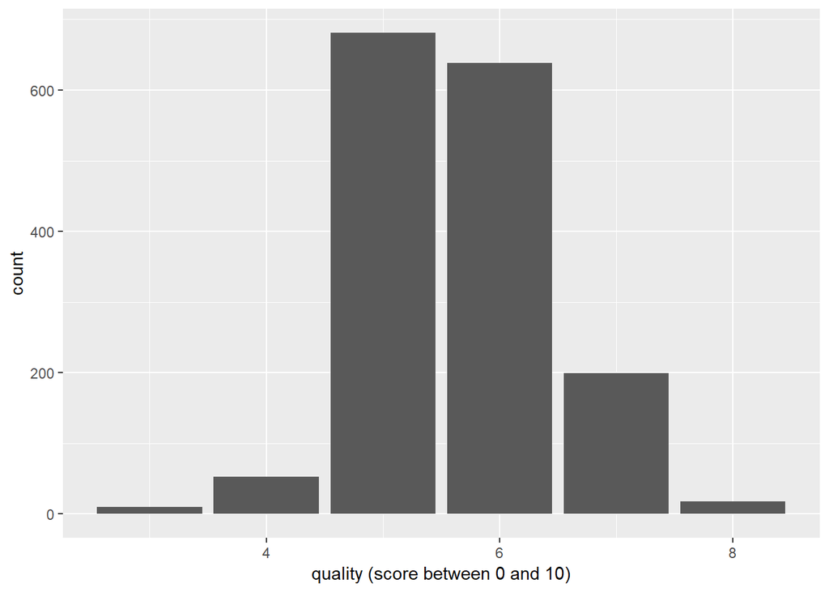

The qulaity is normally distributed among the data, with average of 5~6. Wine quality is distributed with min of 3 and max of 8.

## Alcohol

```
##    Min. 1st Qu.  Median    Mean 3rd Qu.    Max.
##    8.40    9.50   10.20   10.42   11.10   14.90
```

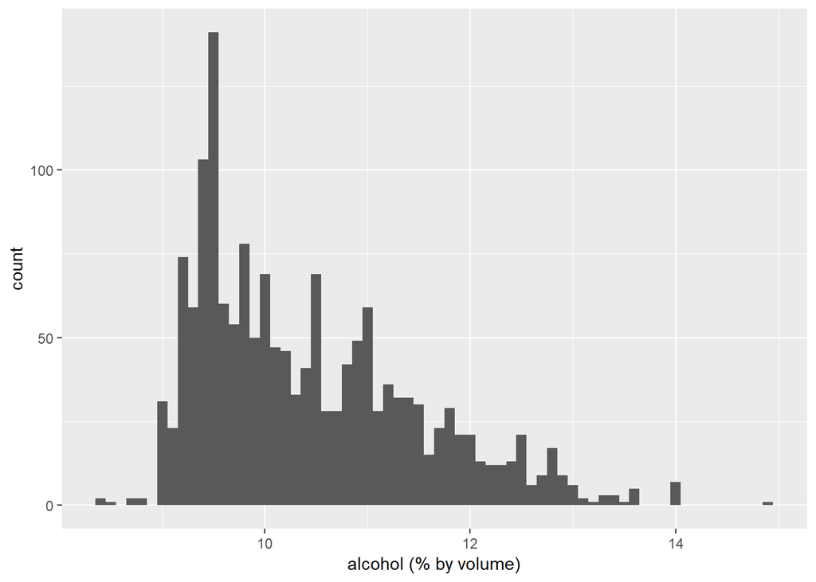

The alcohol distribution is right skewed. The peak of the distribution is at 9.5 and the median value is 10.20. The maximum amount of alcohol present in the dataset is 14.9.

## Density

```
##    Min. 1st Qu.  Median    Mean 3rd Qu.    Max.
##  0.9901  0.9956  0.9968  0.9967  0.9978  1.0037
```

[figure not shown]

## pH

```
##    Min. 1st Qu.  Median    Mean 3rd Qu.    Max.
##   2.740   3.210   3.310   3.311   3.400   4.010
```

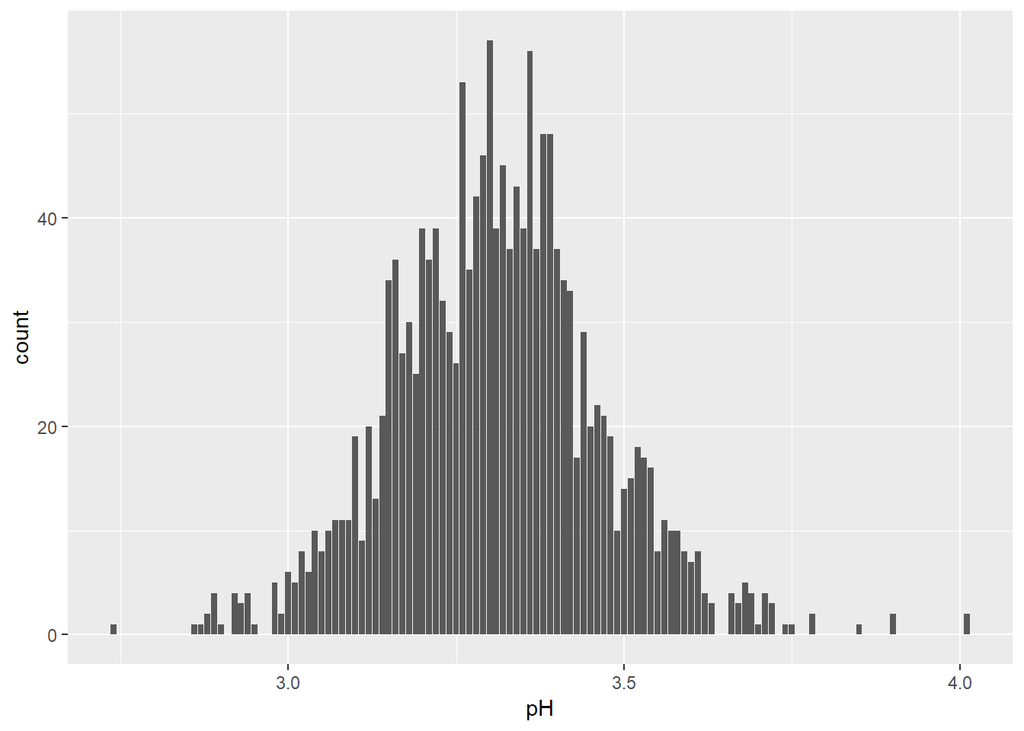

The pH distribution is symmetrical or could be also considered bimodal with both peaks very close to each other. The first peak is at around 3.2 and then another around at 3.35. The median value is 3.31, and most wines have a pH between 3.21 and 3.4.

## Citric acid

```
##    Min. 1st Qu.  Median    Mean 3rd Qu.    Max.
##   0.000   0.090   0.260   0.271   0.420   1.000
```

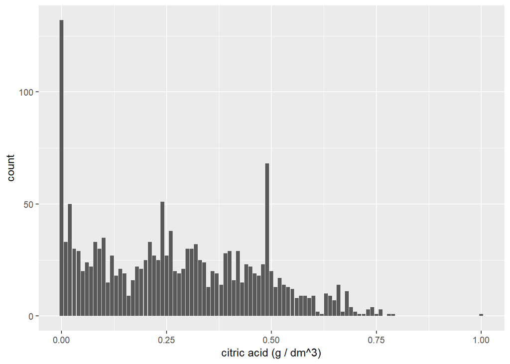

## Total Sulphur Dioxide

```
##    Min. 1st Qu.  Median    Mean 3rd Qu.    Max.
##    6.00   22.00   38.00   46.47   62.00  289.00
```

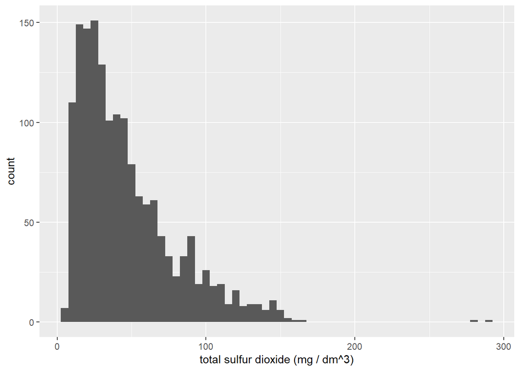

Total Sulphur Dioxide distribution is right skewed with median value of 38 and mean of 46. There’s a gap between 165 and 278 with only two wines with a concentration greater than or equal to 278.

## Free Sulphur Dioxide

```
##    Min. 1st Qu.  Median    Mean 3rd Qu.    Max.
##    1.00    7.00   14.00   15.87   21.00   72.00
```

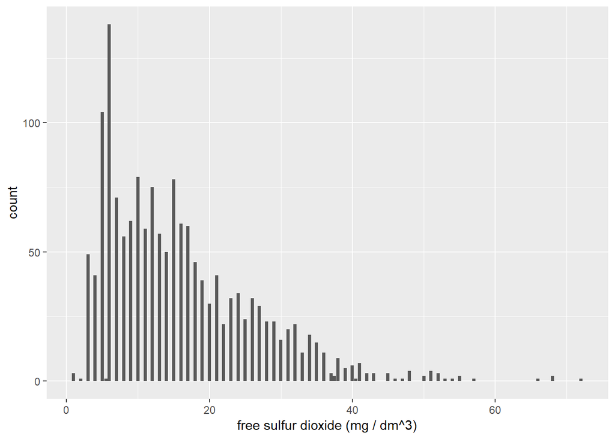

The Free sulfur dioxide distribution is right skewed with median value of 14. The right tail extends until a maximum of 72 with a gap between 57 and 66.

## Residual sugar

```
##    Min. 1st Qu.  Median    Mean 3rd Qu.    Max.
##   0.900   1.900   2.200   2.539   2.600  15.500
```

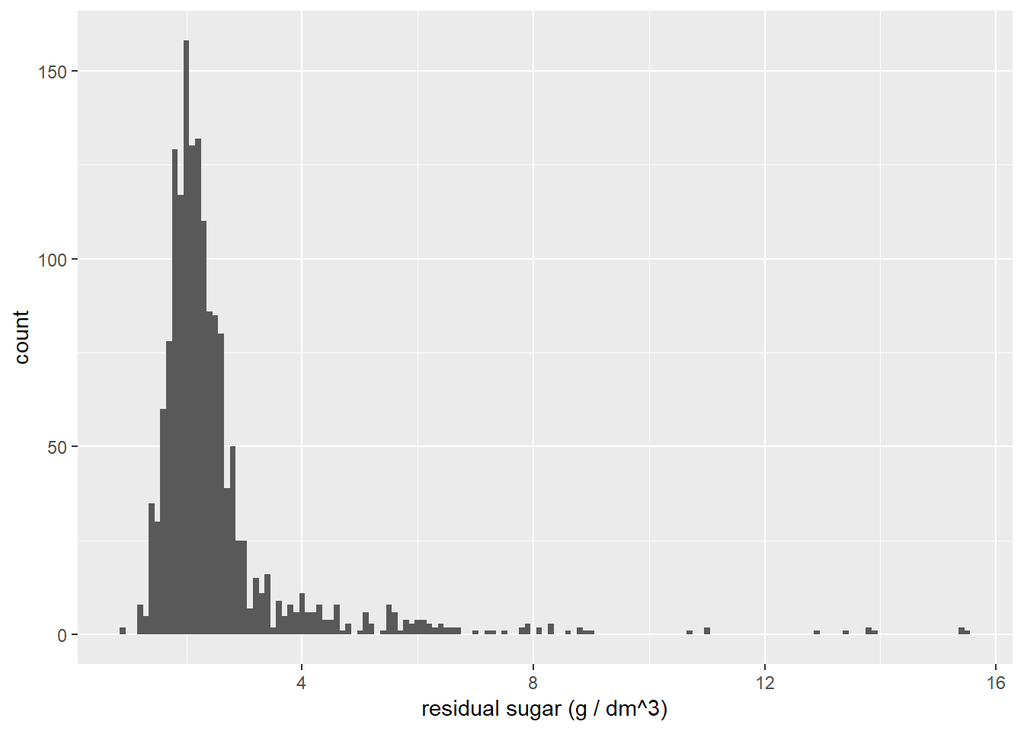

The Residual sugar distibution is right skewed with long tail, the median is 2.2. There are small values from 8 to 16

# Univariate Analysis

### What is the structure of your dataset?

The dataset is about tests made upon 1599 red wine samples. it consists of 12 attributes, 11 numerical values while “Quality” attribute is ordinal

### What is/are the main feature(s) of interest in your dataset?

The main feature, for me, was the quality. Ranked from 3 to 8

### Did you create any new variables from existing variables in the dataset?

No

### Of the features you investigated, were there any unusual distributions? The data is already clean with no null values. No preprocessing was necessary. The distributions are right/left skewed or normally distributed

# Bivariate Plots Section

As “Quality” is, for me, the most important attribute in this dataset. I’ve decided to investigate quality versus the other attributes. From the dataset descriptions we know that the density will depend on the percentage of alcohol and sugar content, so i’m starting with them first

## Quality VS Alcohol

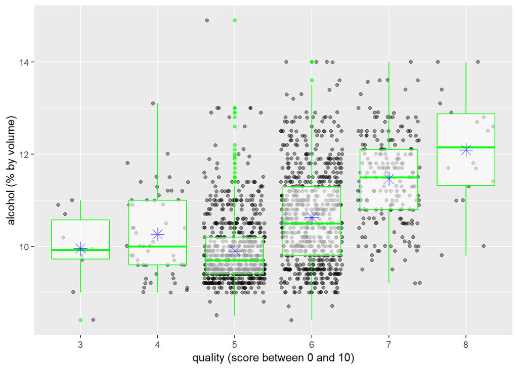

```
## [1] 0.4761663
```

As noticed, most of the quality data is between 5 and 6. Buth the higher the alcohol, the higher the wine quality

## Quality VS Residual Sugar

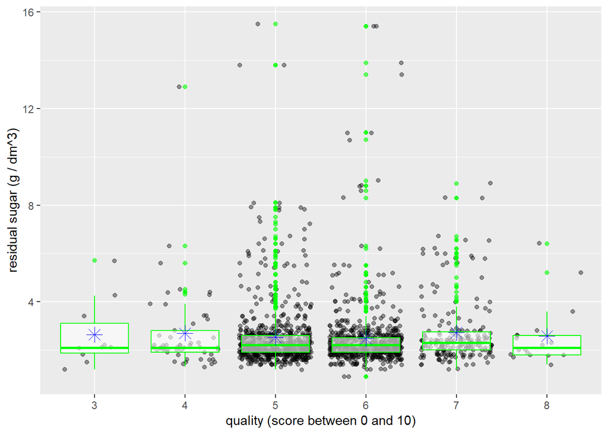

```
## [1] 0.01373164
```

The residual sugar does not have a huge impact on wine quality

## Quality VS Density

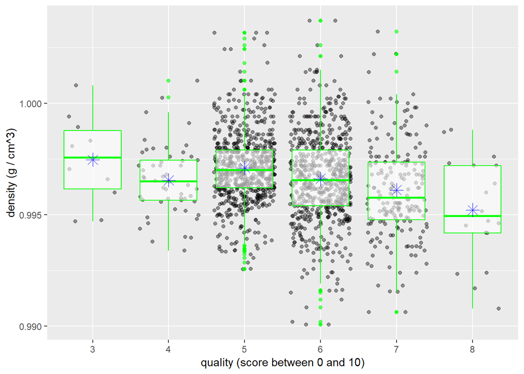

```
## [1] -0.1749192
```

The lower the wine density, the higher the quality

## Quality VS pH

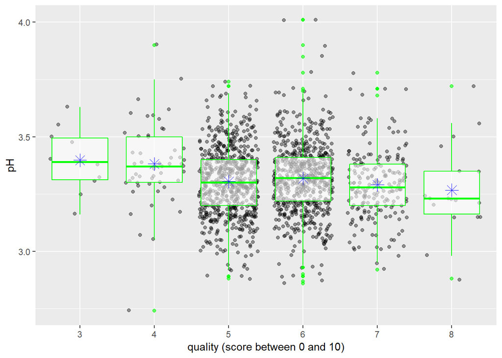

```
## [1] -0.05773139
```

## Quality VS Fixed Acidity

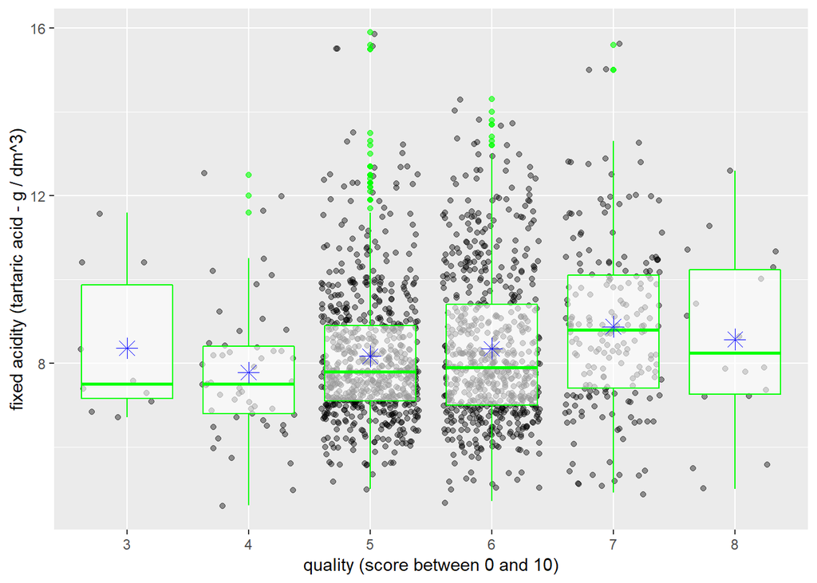

```
## [1] 0.1240516
```

As the collaration value is 0.12, we cannot say that the acidity has positive or negative impact on the wine quality

## Quality VS Volatile Acidity

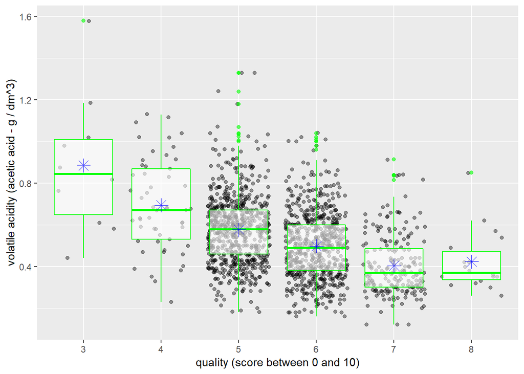

```
## [1] -0.3905578
```

The lower the volatile acidity, the higher the wine quality

## Quality VS Citric Acid

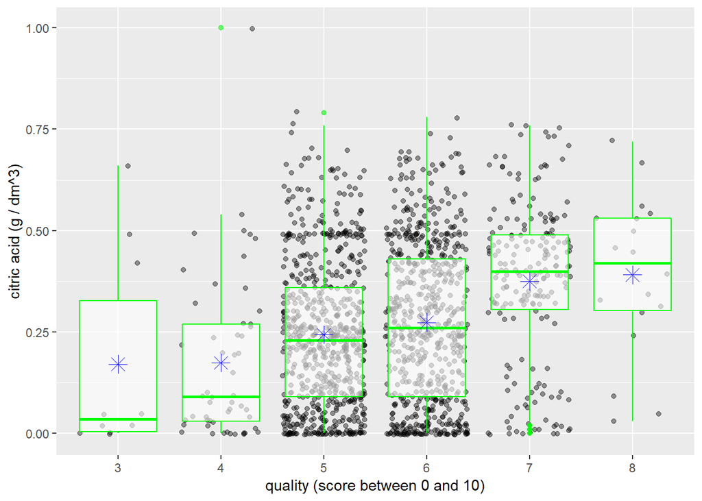

```
## [1] 0.2263725
```

The higher the citric acid, the higher wine quality

## pH VS Citric Acid

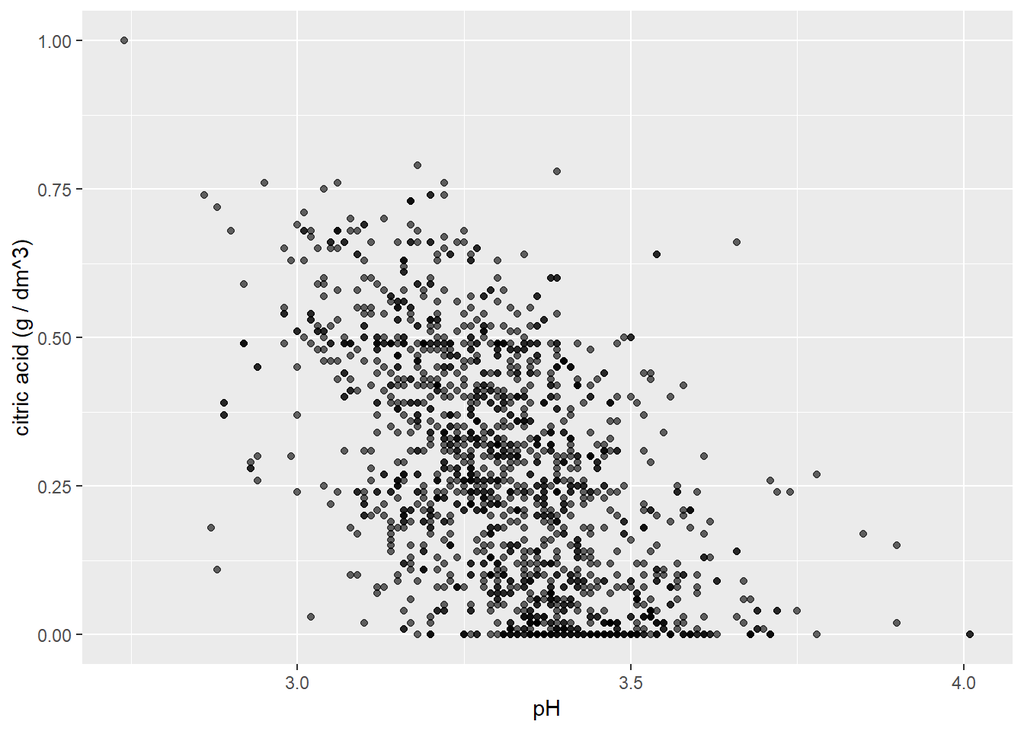

```
## [1] -0.5419041
```

## pH VS Fixed Acidity

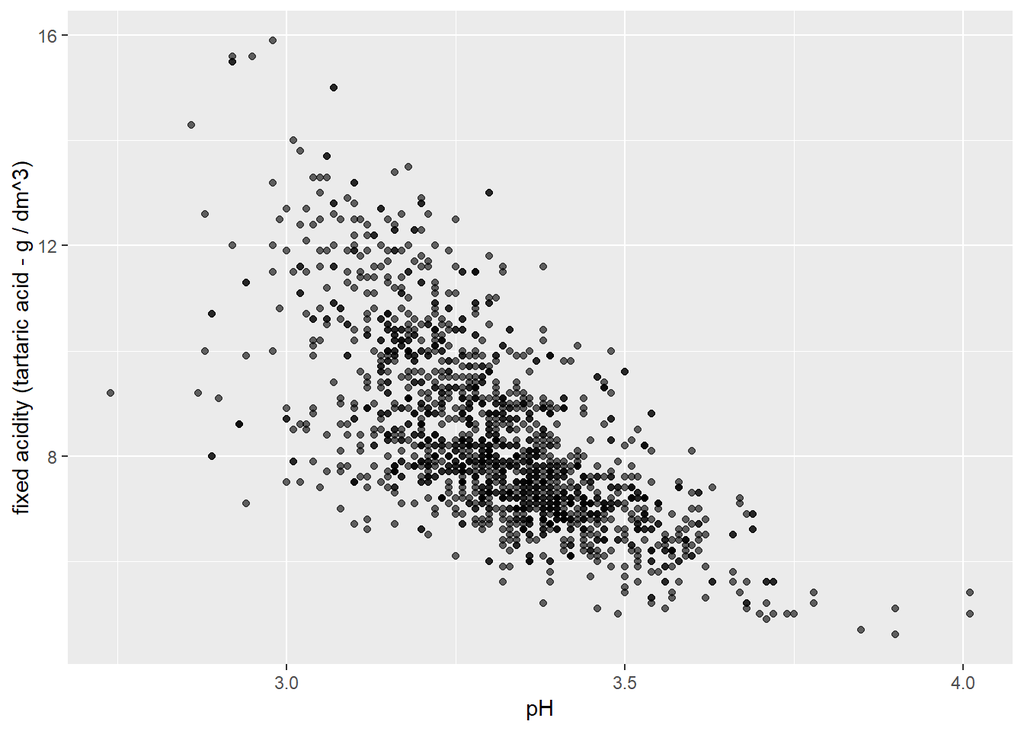

```
## [1] -0.6829782
```

The lower the acid, the higher the wine pH

## pH VS Volatile Acidity

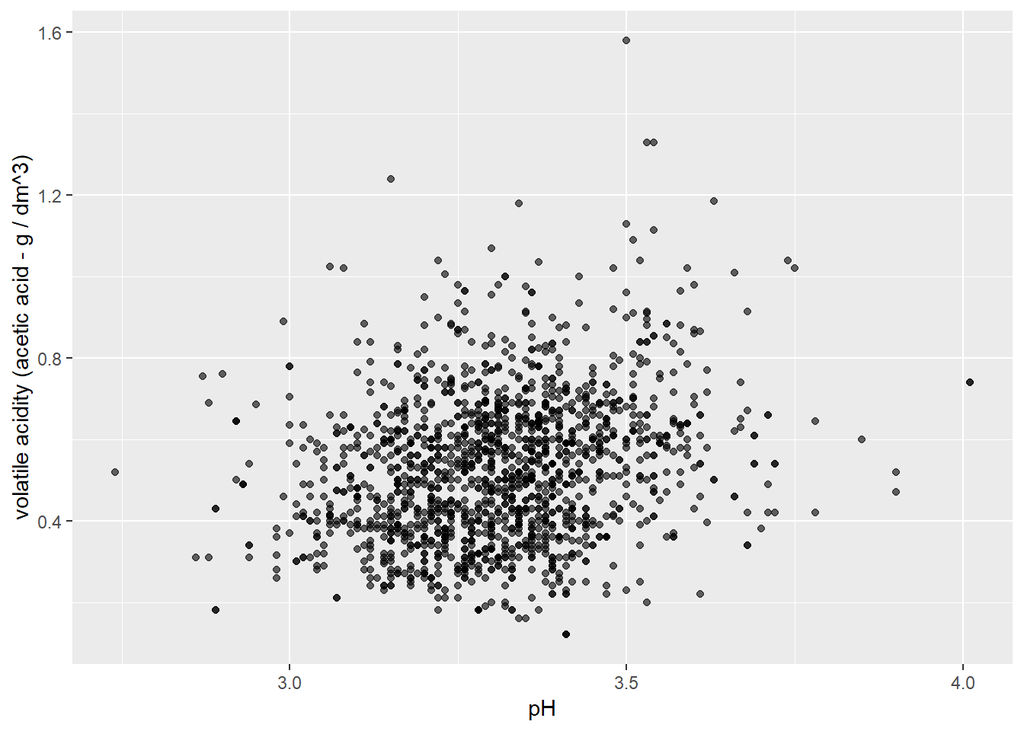

```
## [1] 0.2349373
```

The volatile acidity has no relation with pH although there is a colleration factor between them

## Fixed Acidity VS Volatile Acidity

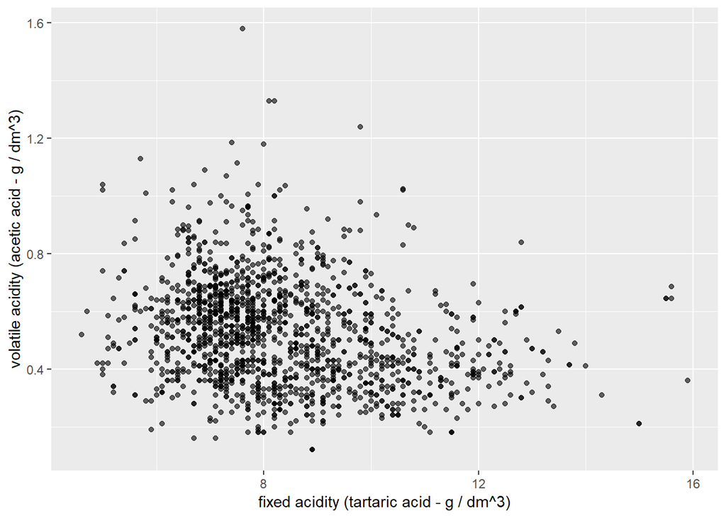

```
## [1] -0.2561309
```

# Bivariate Analysis

### Did you observe any interesting relationships between the other features (not the main feature(s) of interest)?

Quality & Alcohol: The higher the alcohol, the higher the wine quality pH & Fixed Acidity: The lower the acidity, the higher the pH

# Multivariate Plots Section

## Alcohol and Volatile Acidity with Quality

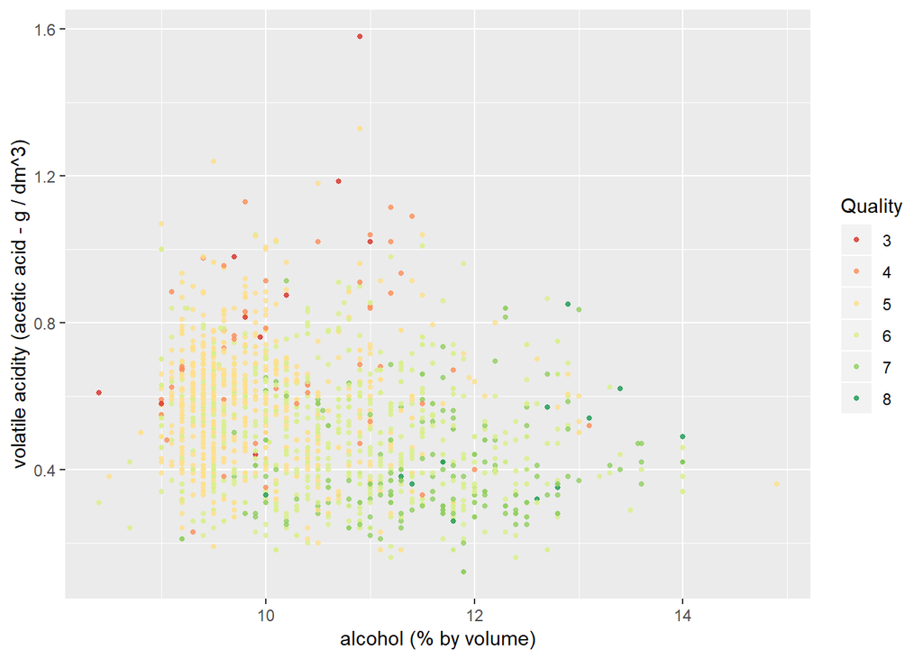

We can tell that the worse quality wines at low alcohol and high volatile acidity

## Citric Acid and Alcohol with Quality

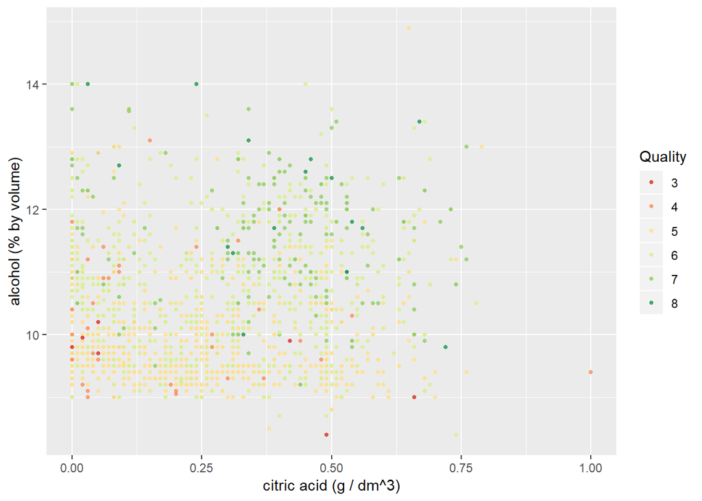

The increase of both citric acid and alcohol tends to give higher quality wines

## Density and Alcohol with Quality

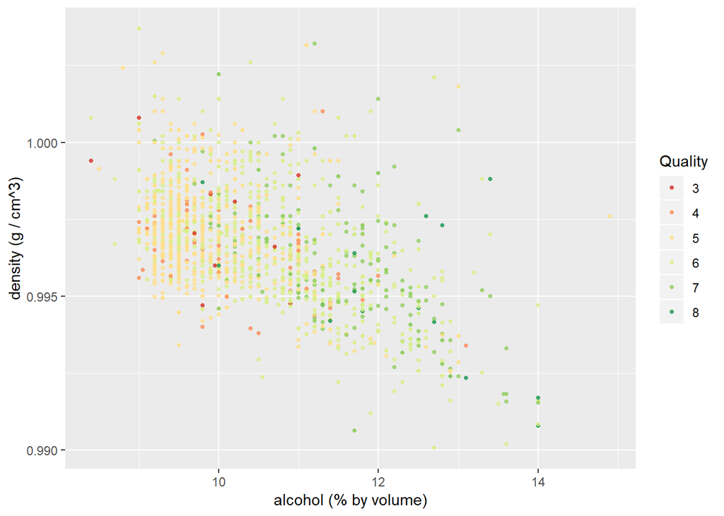

There is a negative relation between density and alcohol concerning the wine quality

# Multivariate Analysis

### Talk about some of the relationships you observed in this part of the investigation. Were there features that strengthened each other in terms of looking at your feature(s) of interest?

The main relationships explored were between the biggest correlators with quality We have noticed how alcohol and volatile acidity relate with quality. Higher alcohol and lower acidity give in general better quality wines Higher amounts of citric acid combined with higher alcohol content gives the best wines

### Were there any interesting or surprising interactions between features?

How alcohol and volatile acidity relate with quality. Higher alcohol and lower acidity give in general better quality wines

# Final Plots and Summary

## Alcohol and Volatile Acid with Quality

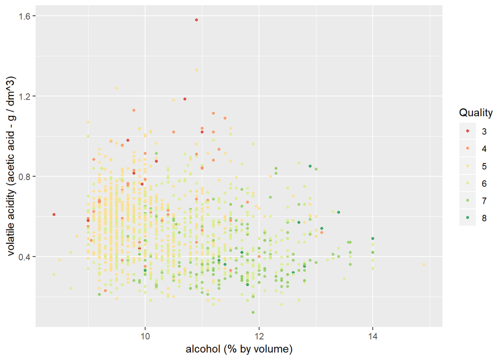

## Alcohol with Quality

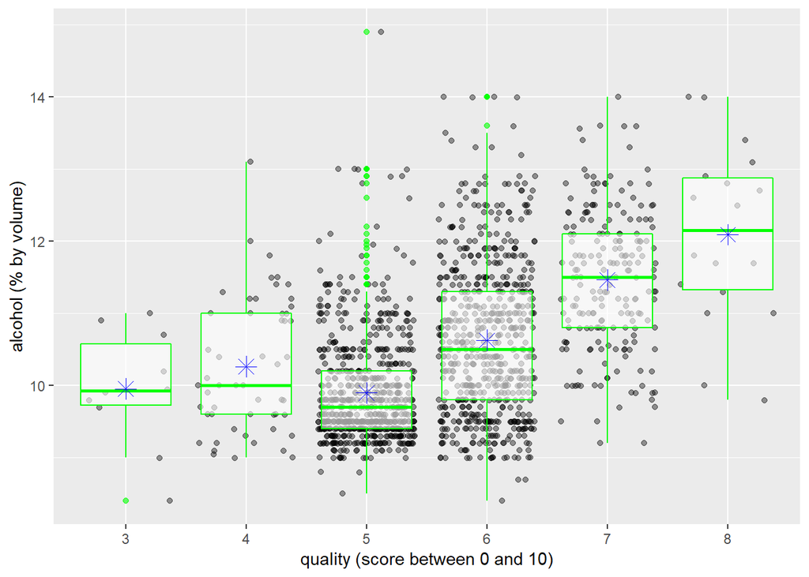

### Description Two

We can notice the big impact of alcohol level on the quality of wines. More Alcohol means better wine

## Alcohol and Citric Acid

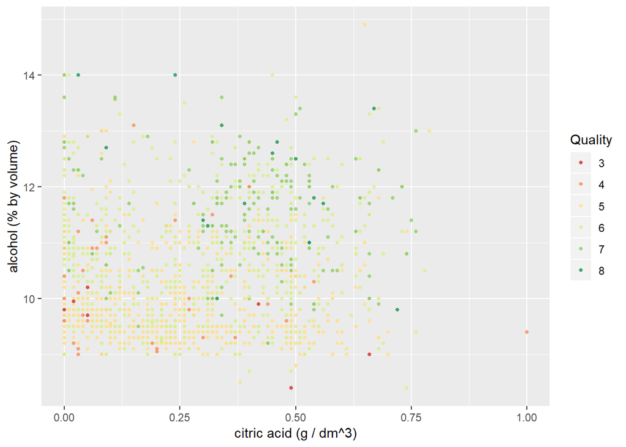

# Reflection

This project was an interesting opportunity to put all the knowledge of the R plotting functionality to explore a real dataset. The dataset was put together for the purpose of applying data analysis techniques and was therefore already very well organized without any missing data The first challenge was the tool itself and the R language. being able to analyze dataset using these tools for the first time was such a good experience Another challenge I faced was interpreting the multivariate plots. When adding a third dimension - in this project, a color was mostly used - it becomes harder to grasp trends. There is no longer a nice line to guide our eyes, but instead the change of color should tell in which directions are our variables evolving In the future, i would like to analyze the white eine dataset to see the difference between the 2 types of wine and maybe we can take a deeper look to each attribute